# 0_Simulation

Arturo Bertero

2025-02-28

```r
library(pacman)
p_load(tidyverse, ggplot2, igraph, ggraph)
```

# Introduction

# Simulation

Suppose in a country we have four parties, and 10 individuals rating them.

```r
# Create example data
df <- tibble::tibble(
  Voter = c(1, 2, 3, 4, 5, 6, 7, 8, 9, 10), # Voter 10 was not present in the original example
  PTV_A = c(10, 0, 10, 10, 10, 10, 5, 10, 4, 10),
  PTV_B = c(0, 0, 0, 9, 5, 0, 0, 5, 4, 10),
  PTV_C = c(0, 0, 0, 0, 0, 5, 0, 5, 3, 10),
  PTV_D = c(0, 10, 9, 0, 5, 5, 0, 5, 3, 10))
```

| *Voter* | *PTV_A* | *PTV_B* | *PTV_C* | *PTV_D* |
| --- | --- | --- | --- | --- |
| 1 | 10 | 0 | 0 | 0 |
| 2 | 0 | 0 | 0 | 10 |
| 3 | 10 | 0 | 0 | 9 |
| 4 | 10 | 9 | 0 | 0 |
| 5 | 10 | 5 | 0 | 5 |
| 6 | 10 | 0 | 5 | 5 |
| 7 | 5 | 0 | 0 | 0 |
| 8 | 10 | 5 | 5 | 5 |
| 9 | 4 | 4 | 3 | 3 |
| 10 | 10 | 10 | 10 | 10 |

Voter 1 and 2 have strong partisanship and AP. 3 and 4 are divided by 2 parties. 5 and 6 are supporter of a party, but also mildly like another one. Voter 7 only likes one party, and not that much. Voter 8 likes all parties, but especially A. Voter 9 dislike most parties. Voter 10 should have min values across the three measures: it has no PTV gap, no AP, min constraint.

I also generate a bigger simulated dataset. Since PTV data are generally skewed to the left, i try to arrive at the same result.

```r
# Set seed
set.seed(1)

# Function to generate skewed PTV values
generate_skewed_ptv <- function(n) {
  return(sample(c(0, 1, 2, 3, 4, 5, 6, 7, 8, 9, 10),
                size = n,
                replace = TRUE,
                prob = c(0.3, 0.15, 0.12, 0.10, 0.09, 0.08, 0.06, 0.05, 0.03, 0.02, 0.01)))
}

# Number of voters
num_voters <- 1000

# Create dataset
df_2 <- tibble(
  Voter = 1:num_voters,
  PTV_A = generate_skewed_ptv(num_voters),
  PTV_B = generate_skewed_ptv(num_voters),
  PTV_C = generate_skewed_ptv(num_voters),
  PTV_D = generate_skewed_ptv(num_voters)
)

#Head
head(df_2)
```

```
## # A tibble: 6 × 5
##   Voter PTV_A PTV_B PTV_C PTV_D
##   <int> <dbl> <dbl> <dbl> <dbl>
## 1     1     0     2     6     5
## 2     2     1     4     8     2
## 3     3     3     1     6     0
## 4     4     7     8     1     1
## 5     5     0     0     0     5
## 6     6     7     0     0     8
```

As a robustenss check, I also generate a df where we have 10 PTVs.

```r
# Create dataset for a 10-party system
df_3 <- tibble(
  Voter = 1:num_voters,
  PTV_A = generate_skewed_ptv(num_voters),
  PTV_B = generate_skewed_ptv(num_voters),
  PTV_C = generate_skewed_ptv(num_voters),
  PTV_D = generate_skewed_ptv(num_voters),
  PTV_E = generate_skewed_ptv(num_voters),
  PTV_F = generate_skewed_ptv(num_voters),
  PTV_G = generate_skewed_ptv(num_voters),
  PTV_H = generate_skewed_ptv(num_voters),
  PTV_I = generate_skewed_ptv(num_voters),
  PTV_J = generate_skewed_ptv(num_voters)
)

# Print
head(df_3)
```

```
## # A tibble: 6 × 11
##   Voter PTV_A PTV_B PTV_C PTV_D PTV_E PTV_F PTV_G PTV_H PTV_I PTV_J
##   <int> <dbl> <dbl> <dbl> <dbl> <dbl> <dbl> <dbl> <dbl> <dbl> <dbl>
## 1     1     0     0     5     4     0     7     0     0     0     5
## 2     2     2     1     4     2     0    10     4     0     0     7
## 3     3     0     0     3     3     5     0     4     0     0     1
## 4     4     2     6     0     3     1     0     0     3     5     2
## 5     5     8     1     7     0     4     0     0     8     0     2
## 6     6     1     1     0     7     0     4     0     7     4     6
```

## Individual level belief systems

We can visualize these PTV structure as individual level belief systems. Edges indicate the absolute perceived distance (i.e.: the abs diff) between all party pairs. This generate a fully connected, weighted, and undirected network, where edges have min = 0 (parties evaluated equally) and max 10 (parties evaluated 10 vs 0).

This code builds the individual level matrices.

```r
# Function to compute absolute difference matrix
compute_difference_matrix <- function(ptv_row) {
  ptv_values <- as.numeric(ptv_row)
  party_labels <- names(ptv_row)

  # Ensure at least two valid PTV values exist
  if (length(ptv_values) < 2) {
    return(NULL)
  }

  # Generate all pairwise combinations of PTV variables
  pairwise_combinations <- expand.grid(Party = party_labels, Compared_Party = party_labels, stringsAsFactors = FALSE)

  # Compute absolute differences for each pair
  pairwise_combinations$Difference <- abs(ptv_values[match(pairwise_combinations$Party, party_labels)] -
                                          ptv_values[match(pairwise_combinations$Compared_Party, party_labels)])

  return(pairwise_combinations)
}

# Apply function to df
df_matrices_list <- map(1:nrow(df), function(i) {
  compute_difference_matrix(df[i, 2:5])
})

# Name each element
names(df_matrices_list) <- df$Voter
```

I also apply the function to the bigger datasets.

```r
# Apply function to df_2
df_matrices_list_2 <- map(1:nrow(df_2), function(i) {
  compute_difference_matrix(df_2[i, 2:5])
})

# Name each element
names(df_matrices_list_2) <- df_2$Voter

# Apply function to df_3
df_matrices_list_3 <- map(1:nrow(df_3), function(i) {
  compute_difference_matrix(df_3[i, 2:5])
})

# Name each element
names(df_matrices_list_3) <- df_3$Voter
```

Now I show a single matrix.

```r
# Print
print(df_matrices_list[[1]])
```

```
##    Party Compared_Party Difference
## 1  PTV_A          PTV_A          0
## 2  PTV_B          PTV_A         10
## 3  PTV_C          PTV_A         10
## 4  PTV_D          PTV_A         10
## 5  PTV_A          PTV_B         10
## 6  PTV_B          PTV_B          0
## 7  PTV_C          PTV_B          0
## 8  PTV_D          PTV_B          0
## 9  PTV_A          PTV_C         10
## 10 PTV_B          PTV_C          0
## 11 PTV_C          PTV_C          0
## 12 PTV_D          PTV_C          0
## 13 PTV_A          PTV_D         10
## 14 PTV_B          PTV_D          0
## 15 PTV_C          PTV_D          0
## 16 PTV_D          PTV_D          0
```

And I visualize the 10 belief systems.

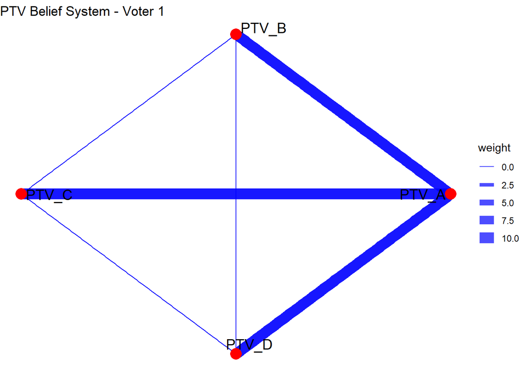

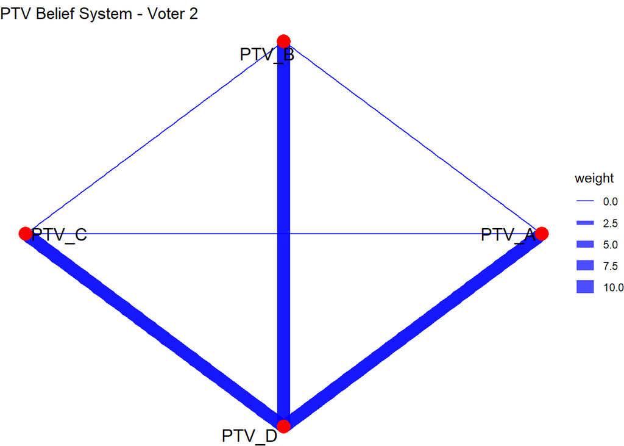

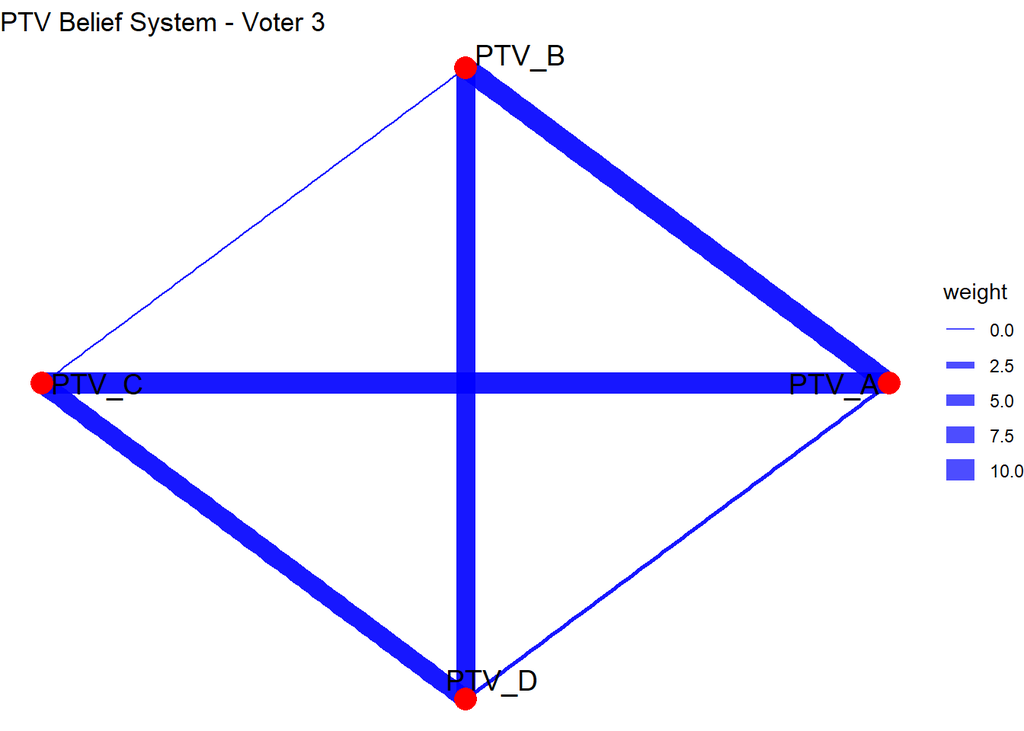

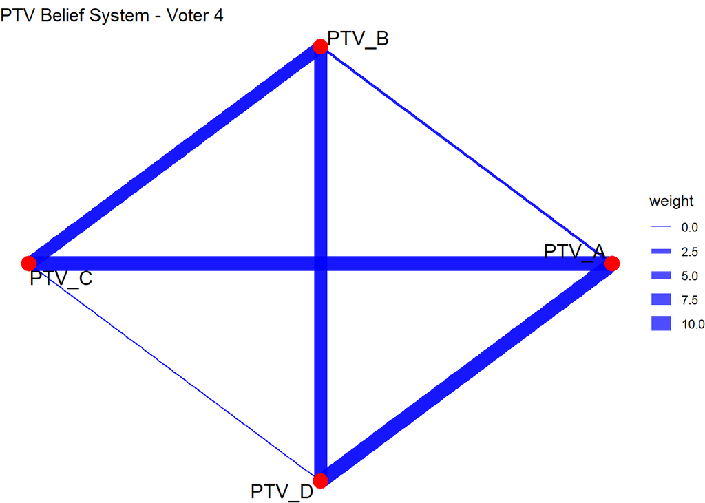

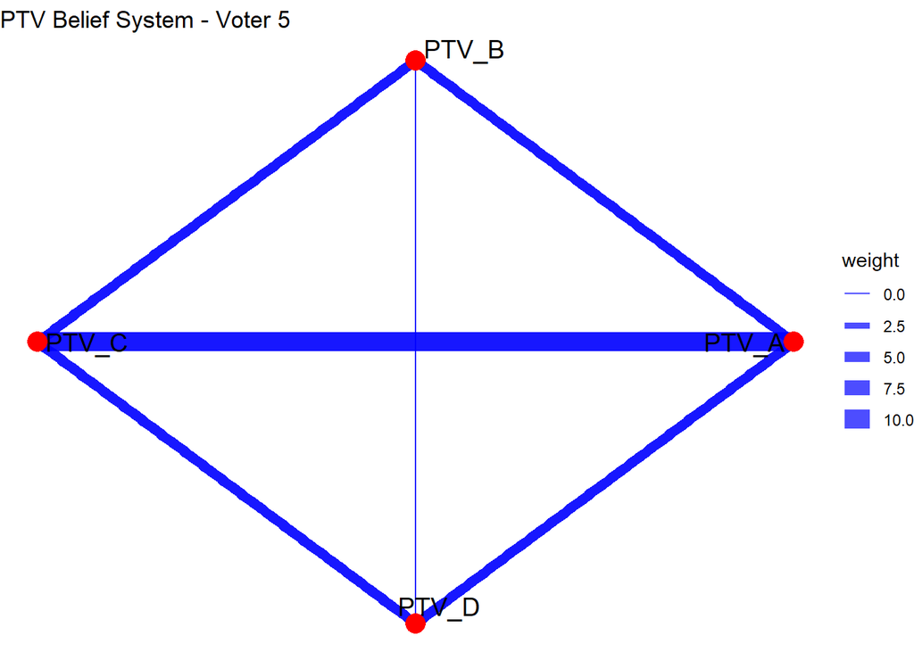

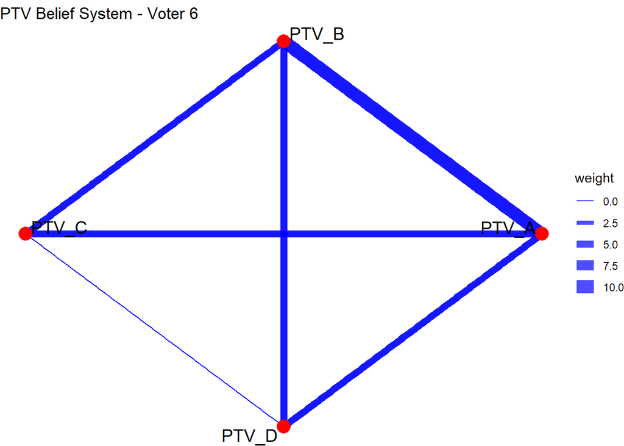

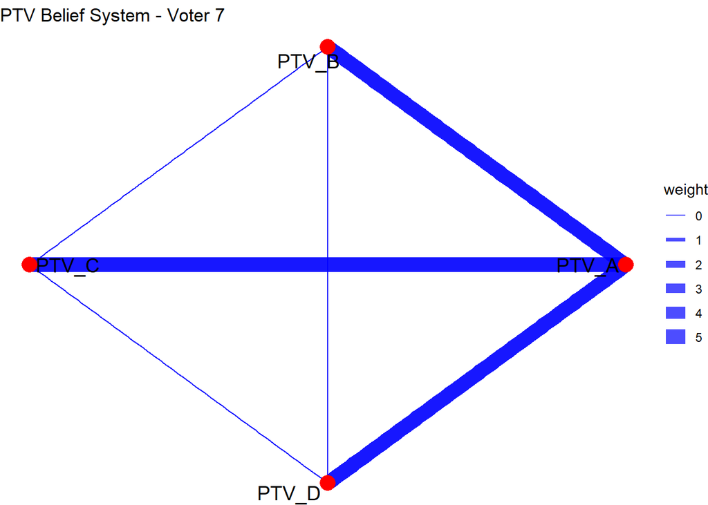

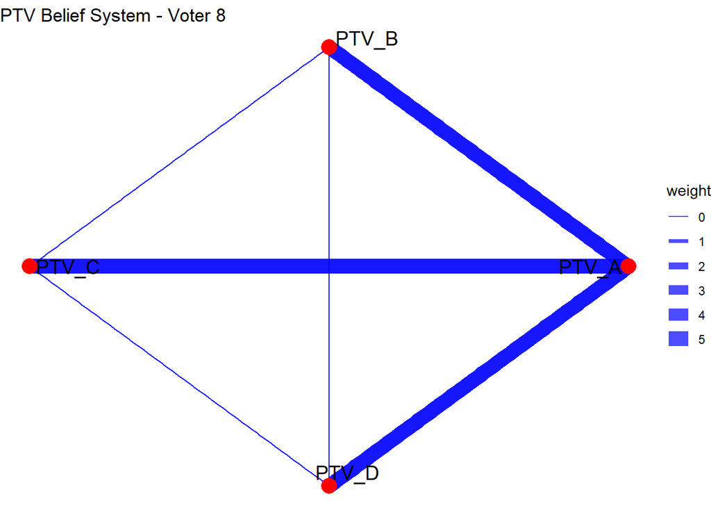

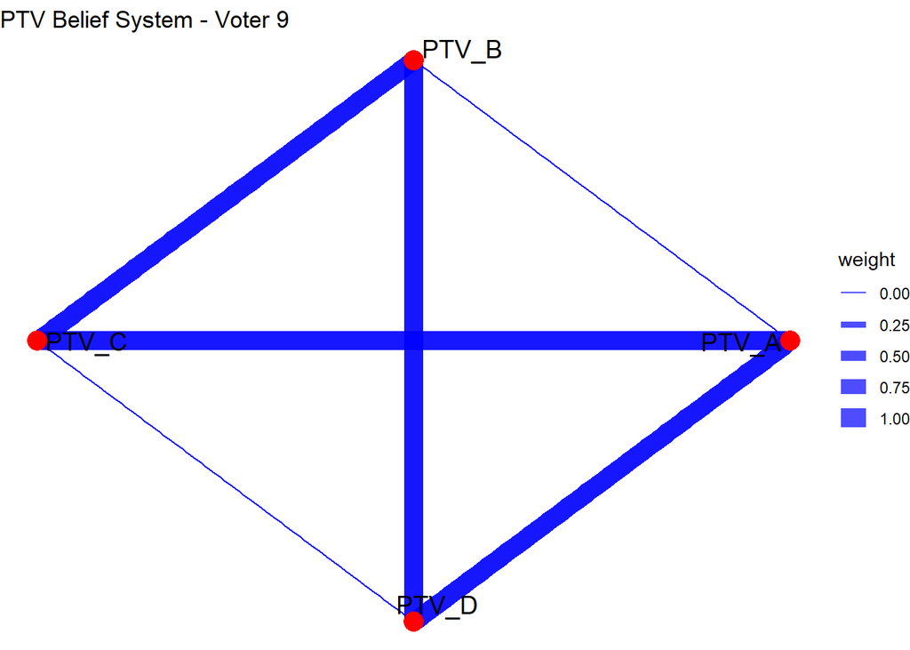

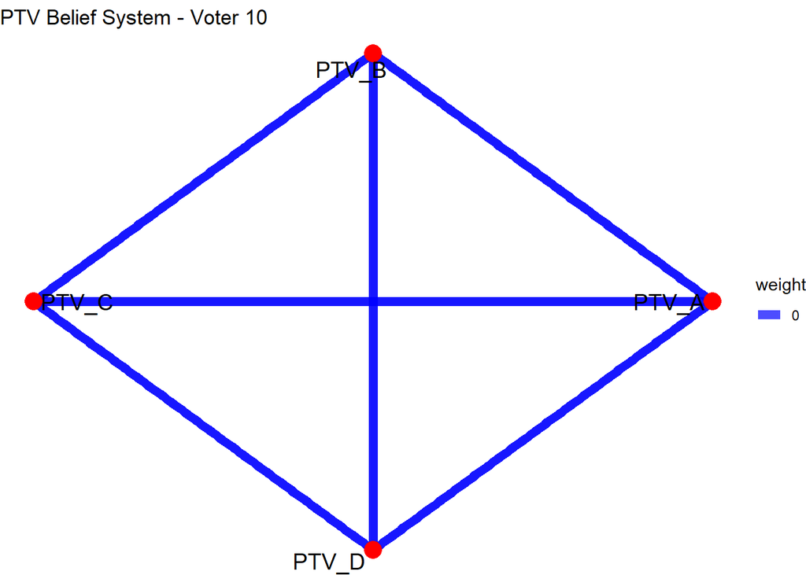

```r
# Function to plot PTV belief system
plot_ptv_network <- function(matrix_data, voter_id) {
  if (is.null(matrix_data) || nrow(matrix_data) == 0) {
    message(paste("Voter", voter_id, ": No valid PTV differences to plot."))
    return(NULL)
  }

  # Convert to igraph
  g <- graph_from_data_frame(matrix_data, directed = FALSE)

  # Set edge weights
  E(g)$weight <- matrix_data$Difference

  # Plot network using ggraph
  ggraph(g, layout = "circle") +
    geom_edge_link(aes(width = weight), color = "blue", alpha = 0.7) +
    geom_node_point(size = 5, color = "red") +
    geom_node_text(aes(label = name), repel = TRUE, size = 5) +
    scale_edge_width(range = c(0.5, 5)) +  # Scale edge weights
    theme_void() +
    labs(title = paste("PTV Belief System - Voter", voter_id))
}

# Loop for fitting to all voters
for (i in seq_along(df_matrices_list)) {
  print(plot_ptv_network(df_matrices_list[[i]], names(df_matrices_list)[i]))
}
```

The belief systems behave as expected, but matrices present some problems: they are symmetrical. This means that we can not compute the Constraint measure directly on the full matrix, as this would bias the final output. Indeed, in countries with more parties we have lower constrain by design: there are more 0s, due to the higher number of zero differences obtained when computing differences between the PTV scores of the same party. For example, in a country with 4 parties we have 4 0s by design (diff between Party A and A, B-B, C-C, D-D). These are 5 0s when we have 5 parties.

## PTV measures

We start from the easiest measure. We compute the PTV gap, on all datasets.

```r
# Compute PTV Gap (Max - Second Max)
df <- df %>%
  rowwise() %>%
  mutate(
    PTV_Gap = {
      sorted_scores <- sort(c_across(PTV_A:PTV_D), decreasing = TRUE)
      ifelse(length(sorted_scores) >= 2, sorted_scores[1] - sorted_scores[2], NA)
    }
  ) %>%
  ungroup()

# Compute PTV Gap on df_2
df_2 <- df_2 %>%
  rowwise() %>%
  mutate(
    PTV_Gap = {
      sorted_scores <- sort(c_across(PTV_A:PTV_D), decreasing = TRUE)
      ifelse(length(sorted_scores) >= 2, sorted_scores[1] - sorted_scores[2], NA)
    }
  ) %>%
  ungroup()

# Compute PTV Gap on df_3
df_3 <- df_3 %>%
  rowwise() %>%
  mutate(
    PTV_Gap = {
      sorted_scores <- sort(c_across(PTV_A:PTV_D), decreasing = TRUE)
      ifelse(length(sorted_scores) >= 2, sorted_scores[1] - sorted_scores[2], NA)
    }
  ) %>%
  ungroup()
```

Now we compute AP, using Magnus Wagner’s famous formula. There are many versions. The main differences is between weighted and unweighted measures. Weighted ones take into account how big/small is a party. I avoid computing these, as they are challenging to compute in the horrible EES dataset where parties are stored in character format, not with party codes. This makes a nightmare retrieving info on their vote shares. So I resort to the unweighted measure of mean distance from the most-liked party.

```r
# Compute Affective Polarization using Wagner's Formula
df <- df %>%
  rowwise() %>%
  mutate(
    like_max = max(c_across(PTV_A:PTV_D), na.rm = TRUE),  # Identify the most liked party
    n_p = sum(!is.na(c_across(PTV_A:PTV_D))) - 1,  # Count the number of other parties
    AP = ifelse(n_p > 0, sqrt(sum((c_across(PTV_A:PTV_D) - like_max)^2, na.rm = TRUE) / n_p), NA)
  ) %>%
  ungroup() %>%
  select(-like_max, -n_p)  # Drop intermediate variables

# Compute ap on df_2
df_2 <- df_2 %>%
  rowwise() %>%
  mutate(
    like_max = max(c_across(PTV_A:PTV_D), na.rm = TRUE),  # Identify the most liked party
    n_p = sum(!is.na(c_across(PTV_A:PTV_D))) - 1,  # Count the number of other parties
    AP = ifelse(n_p > 0, sqrt(sum((c_across(PTV_A:PTV_D) - like_max)^2, na.rm = TRUE) / n_p), NA)
  ) %>%
  ungroup() %>%
  select(-like_max, -n_p)  # Drop intermediate variables

# Compute ap on df_3
df_3 <- df_3 %>%
  rowwise() %>%
  mutate(
    like_max = max(c_across(PTV_A:PTV_D), na.rm = TRUE),  # Identify the most liked party
    n_p = sum(!is.na(c_across(PTV_A:PTV_D))) - 1,  # Count the number of other parties
    AP = ifelse(n_p > 0, sqrt(sum((c_across(PTV_A:PTV_D) - like_max)^2, na.rm = TRUE) / n_p), NA)
  ) %>%
  ungroup() %>%
  select(-like_max, -n_p)  # Drop intermediate variables
```

Finally, we work with the upper triangle of the matrices and calculate mean constraint. In this way we avoid self-comparison.

```r
# Function to compute Mean Constraint
compute_mean_constraint <- function(ptv_row) {
  ptv_values <- as.numeric(ptv_row)

  # Ensure at least 2 parties are rated
  if (sum(!is.na(ptv_values)) < 2) {
    return(NA_real_)
  }

  # Generate all pairwise absolute differences (excluding self-comparisons)
  pairwise_differences <- combn(ptv_values, 2, function(x) abs(diff(x))) # combn only selects unique pairs

  # Compute the average absolute pairwise difference
  return(mean(pairwise_differences, na.rm = TRUE))
}

# Apply function on df
df <- df %>%
  rowwise() %>%
  mutate(Mean_Constraint = compute_mean_constraint(c_across(PTV_A:PTV_D))) %>%
  ungroup()

df = round(df, 3)

# Apply function on df_2
df_2 <- df_2 %>%
  rowwise() %>%
  mutate(Mean_Constraint = compute_mean_constraint(c_across(PTV_A:PTV_D))) %>%
  ungroup()

df_2 = round(df_2, 3)

# Apply function on df_3
df_3 <- df_3 %>%
  rowwise() %>%
  mutate(Mean_Constraint = compute_mean_constraint(c_across(PTV_A:PTV_D))) %>%
  ungroup()

df_3 = round(df_3, 3)
```

Let’s visualize a comparison of the measures.

| *Voter* | *PTV_A* | *PTV_B* | *PTV_C* | *PTV_D* | *PTV_GAP* | *AP* | *Constraint* |
| --- | --- | --- | --- | --- | --- | --- | --- |
| 1 | 10 | 0 | 0 | 0 | 10 | 10 | 5 |
| 2 | 0 | 0 | 0 | 10 | 10 | 10 | 5 |
| 3 | 10 | 0 | 0 | 9 | 1 | 8.18 | 6.5 |
| 4 | 10 | 9 | 0 | 0 | 1 | 8.18 | 6.5 |
| 5 | 10 | 5 | 0 | 5 | 5 | 7.07 | 5 |
| 6 | 10 | 0 | 5 | 5 | 5 | 7.07 | 5 |
| 7 | 5 | 0 | 0 | 0 | 5 | 5 | 2.5 |
| 8 | 10 | 5 | 5 | 5 | 5 | 5 | 2.5 |
| 9 | 4 | 4 | 3 | 3 | 0 | 0.816 | 0.667 |
| 10 | 10 | 10 | 10 | 10 | 0 | 0.000 | 0.000 |

So, the key difference between our measure and the others is that constraint works with every pair of party differences. This means it is actually at its max when absolute differences are maximized (voters 3 and 4), and not when voters have a clear preference for a single party (voters 1 and 2). Moreover, for our measure, situations of voters 1 and 2 is identical to those of voters 5 and 6. I think this could make sense. For voter 1, all parties but A are not a viable option. In case that party betrays him/her there is no other option than abstention. However, in case voter 5 is betrayed by party A, voting for other parties should be more likely.

```r
max_4parties = max(df$Mean_Constraint)
max_4parties_2 = max(df_2$Mean_Constraint)
max_10parties = max(df_3$Mean_Constraint)

# Print
max_4parties
```

```
## [1] 6.5
```

```r
max_4parties_2
```

```
## [1] 6.5
```

```r
max_10parties
```

```
## [1] 6.333
```